# *Projet :*

## 4.3 ACP2:

Sélectionner les colonnes numériques pour l’ACP de les facteurs sociaux et productivites:

```r
donnees_num2 <- donnees[, 17:28]
donnees_num2 <- na.omit(donnees_num2)  # Supprimer les lignes avec NA
```

### 4.3.1-Réaliser l’ACP:

```r
res.pca2 <- PCA(donnees_num2, scale.unit = TRUE, graph = FALSE)
```

### 4.3.2- Les axes à conserver

On utilise les critères du taux d’inertie cumulée, de Kaiser, et du coude :

```
##          eigenvalue variance.percent cumulative.variance.percent
## Dim.1  9.207199e+00     7.672666e+01                    76.72666
## Dim.2  1.621354e+00     1.351129e+01                    90.23795
## Dim.3  6.635653e-01     5.529711e+00                    95.76766
## Dim.4  2.158576e-01     1.798814e+00                    97.56647
## Dim.5  1.076269e-01     8.968911e-01                    98.46336
## Dim.6  9.640785e-02     8.033987e-01                    99.26676
## Dim.7  4.789063e-02     3.990886e-01                    99.66585
## Dim.8  2.299447e-02     1.916206e-01                    99.85747
## Dim.9  1.099888e-02     9.165734e-02                    99.94913
## Dim.10 3.924187e-03     3.270156e-02                    99.98183
## Dim.11 2.180449e-03     1.817041e-02                   100.00000
## Dim.12 2.025227e-32     1.687689e-31                   100.00000
```

**Critère de Kaiser** :On conserve les axes avec une valeur propre > 1:

d’après ce critère on conserve 2 axes pour valeurs propres : (9.207 ,1.62)

**Critère d’inertie cumulée** : On retient les axes expliquant 70-80 % de la variance.

les deux premiers axes ont un taux d’inertie de 90%

Decision: on va conserver les deux axes 1 et 2

**Critère du coude** :

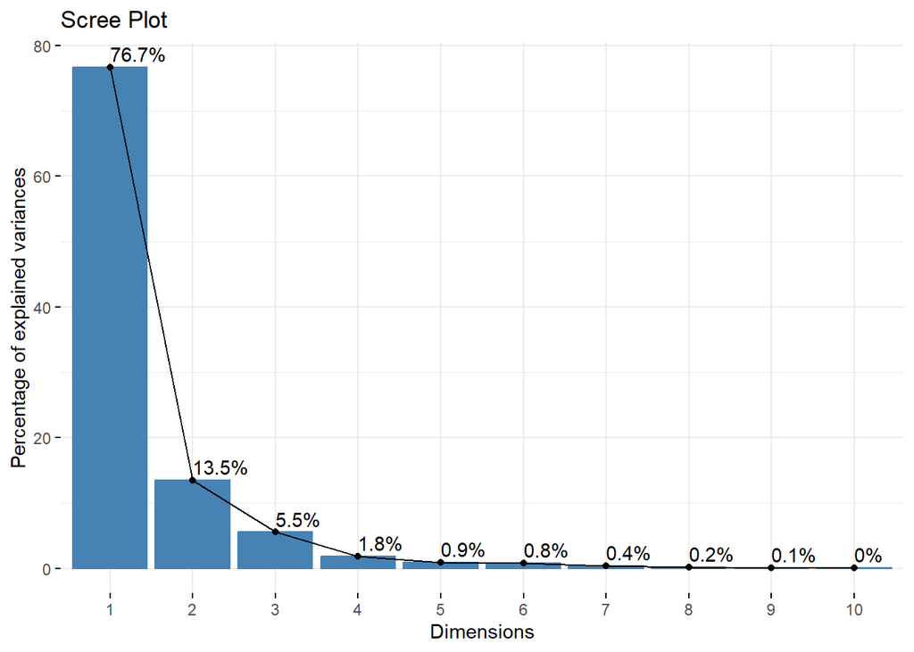

```r
# Scree plot pour visualiser la variance expliquée
fviz_eig(res.pca2, addlabels = TRUE, title = "Scree Plot")
```

la coude est au niveau de deuxiéme axe .

Decision: donc on va conserver les deux premiers axes

**Décision finale** : On retient 2 axes.

### 4.3.3- Interprétation des axes:

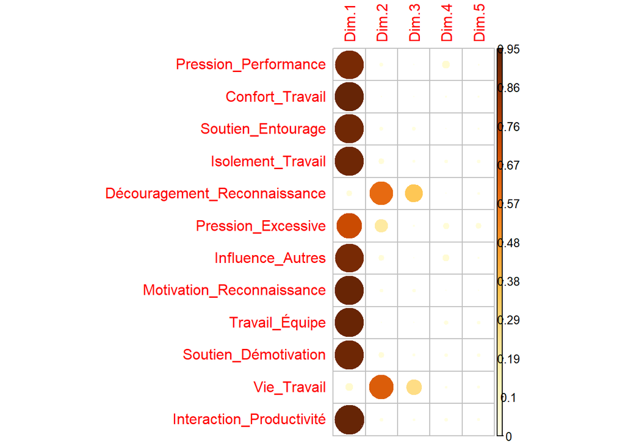

```r
library(corrplot)
var2 <- get_pca_var(res.pca2)
corrplot(var2$cos2, is.corr = FALSE)
```

```r
var2$coord
```

```
##                                   Dim.1      Dim.2        Dim.3        Dim.4
## Pression_Performance          0.9514613 0.12423176  0.013564676  0.243701132
## Confort_Travail               0.9745613 0.03683395  0.002253531  0.065193179
## Soutien_Entourage             0.9626390 0.11742509  0.121868670 -0.002872329
## Isolement_Travail            -0.9652266 0.18554285  0.093413990  0.104378844
## Découragement_Reconnaissance -0.1838336 0.78251388 -0.588625546  0.021541813
## Pression_Excessive            0.8462384 0.43822896 -0.067790043 -0.202610564
## Influence_Autres             -0.9519641 0.19369075  0.034098126  0.221093875
## Motivation_Reconnaissance     0.9714035 0.10913691  0.106895398  0.026202912
## Travail_Équipe                0.9730169 0.03844876 -0.017397786  0.142889493
## Soutien_Démotivation         -0.9652266 0.18554285  0.093413990  0.104378844
## Vie_Travail                  -0.2521605 0.80881059  0.511582154 -0.077865548
## Interaction_Productivité      0.9757208 0.11167212  0.073403690  0.113377507
##                                    Dim.5
## Pression_Performance         -0.04752597
## Confort_Travail               0.06646084
## Soutien_Entourage             0.06514251
## Isolement_Travail             0.10769067
## Découragement_Reconnaissance -0.07128024
## Pression_Excessive            0.19001991
## Influence_Autres              0.06053507
## Motivation_Reconnaissance    -0.03321900
## Travail_Équipe                0.10707529
## Soutien_Démotivation          0.10769067
## Vie_Travail                  -0.09157081
## Interaction_Productivité     -0.08778551
```

### il faut savoir que :

### Plus le cos2 est élevé plus la variable est mieux représentée.

```r
res.pca2$var$coord
```

```
##                                   Dim.1      Dim.2        Dim.3        Dim.4
## Pression_Performance          0.9514613 0.12423176  0.013564676  0.243701132
## Confort_Travail               0.9745613 0.03683395  0.002253531  0.065193179
## Soutien_Entourage             0.9626390 0.11742509  0.121868670 -0.002872329
## Isolement_Travail            -0.9652266 0.18554285  0.093413990  0.104378844
## Découragement_Reconnaissance -0.1838336 0.78251388 -0.588625546  0.021541813
## Pression_Excessive            0.8462384 0.43822896 -0.067790043 -0.202610564
## Influence_Autres             -0.9519641 0.19369075  0.034098126  0.221093875
## Motivation_Reconnaissance     0.9714035 0.10913691  0.106895398  0.026202912
## Travail_Équipe                0.9730169 0.03844876 -0.017397786  0.142889493
## Soutien_Démotivation         -0.9652266 0.18554285  0.093413990  0.104378844
## Vie_Travail                  -0.2521605 0.80881059  0.511582154 -0.077865548
## Interaction_Productivité      0.9757208 0.11167212  0.073403690  0.113377507
##                                    Dim.5
## Pression_Performance         -0.04752597
## Confort_Travail               0.06646084
## Soutien_Entourage             0.06514251
## Isolement_Travail             0.10769067
## Découragement_Reconnaissance -0.07128024
## Pression_Excessive            0.19001991
## Influence_Autres              0.06053507
## Motivation_Reconnaissance    -0.03321900
## Travail_Équipe                0.10707529
## Soutien_Démotivation          0.10769067
## Vie_Travail                  -0.09157081
## Interaction_Productivité     -0.08778551
```